# NITRATE CONCENTRATIONS IN SURFACE WATER by Tim Franken

# Introduction to the data

The dataset for this project is a datset related to water quality measurements in small rivers in Flanders. The dataset has 4211 rows of 15 variables:

- nitrate: Yearly maximum nitrate concentration in the river [mg N/L]
- year: Year of measurement
- rainfall: Cumulative rainfall in the month leading up to the measurement [mm]
- oxygen: Oxygen saturation [%]
- area: area of farmland divided by total upstream area [%]. 0 –> no farming, 1 –> all farmland
- emission: emmission of N by animals divided by area of farmland [kg / m²]
- stockage: stockage of manure in a year [kg / m²]
- grass: area of grass divided by area of farmland
- vegetableG1: area of vegetables in group G1 divided by area of farmland [%]
- vegetableG2: area of vegetables in group G2 divided by area of farmland [%]
- vegetableG3: area of vegetables in group G3 divided by area of farmland [%]
- catchcrop: Factor indicating whether yes or no a catchcrop is planted. (https://en.wikipedia.org/wiki/Catch_crop)
- norm_N: threshold of N to be applied on the field [kg/m²]
- depostion: depostion of N from the air in the total upstream area [kg/m²]

What we are mainly interested here is to see if any of these variables can explain the variance in the nitrate concentrations in the river.

First, let’s take a look at the general structure of the data and some summaries.

```
## 'data.frame':    4211 obs. of  15 variables:
##  $ gridcode   : int  6029 6029 6029 6029 6029 6029 7003 7003 7003 7003 ...
##  $ year       : Factor w/ 6 levels "2008","2009",..: 1 2 3 4 5 6 1 2 3 4 ...
##  $ nitrate    : num  7.7 1.4 5.6 4.2 4.5 2.27 5.3 4.4 0.89 10.5 ...
##  $ rainfall   : num  74.1 175.5 197 181.1 142.4 ...
##  $ oxygen     : num  28 24.5 0 0 0 0 0 36.8 0 72.4 ...
##  $ area       : num  0.822 0.827 0.815 0.811 0.823 ...
##  $ emission   : num  0.00409 0.00188 0.00118 0.00142 0.00138 ...
##  $ stockage   : num  9.35e-04 1.80e-05 2.76e-04 4.00e-04 7.53e-05 ...
##  $ grass      : num  0.315 0.311 0.308 0.326 0.31 ...
##  $ vegetableG1: num  0 0 0 0 0 0 0 0 0 0 ...
##  $ vegetableG2: num  0 0 0 0 0 ...
##  $ vegetableG3: num  0 0 0 0.0621 0.056 ...
##  $ catchcrop  : Factor w/ 2 levels "no","yes": 1 1 1 1 1 1 1 2 1 1 ...
##  $ norm_N     : num  0.0273 0.026 0.0261 0.0265 0.025 ...
##  $ deposition : num  0.00335 0.00295 0.00275 0.003 0.00295 ...
```

```
##   gridcode year nitrate  rainfall oxygen      area    emission    stockage
## 1     6029 2008    7.70  74.07855   28.0 0.8216872 0.004091141 0.000935199
## 2     6029 2009    1.40 175.45683   24.5 0.8267721 0.001880426 0.000018000
## 3     6029 2010    5.60 196.97829    0.0 0.8149374 0.001175205 0.000275908
## 4     6029 2011    4.20 181.13259    0.0 0.8106787 0.001416772 0.000400237
## 5     6029 2012    4.50 142.39708    0.0 0.8231414 0.001375541 0.000075300
## 6     6029 2013    2.27 100.74699    0.0 0.8105691 0.001516504 0.000002720
##       grass vegetableG1 vegetableG2 vegetableG3 catchcrop     norm_N
## 1 0.3152916           0           0  0.00000000        no 0.02726997
## 2 0.3105353           0           0  0.00000000        no 0.02601755
## 3 0.3081071           0           0  0.00000000        no 0.02613871
## 4 0.3257532           0           0  0.06210519        no 0.02646171
## 5 0.3097630           0           0  0.05597486        no 0.02503786
## 6 0.3132281           0           0  0.06726274        no 0.02534691
##    deposition
## 1 0.003346485
## 2 0.002950213
## 3 0.002749278
## 4 0.002999704
## 5 0.002945348
## 6 0.002622745
```

```
##     gridcode        year        nitrate         rainfall
##  Min.   :  6029   2008:702   Min.   : 0.10   Min.   :  0.00
##  1st Qu.:232550   2009:691   1st Qu.: 2.60   1st Qu.: 57.83
##  Median :449650   2010:689   Median : 6.40   Median : 79.85
##  Mean   :467294   2011:721   Mean   : 7.78   Mean   : 87.71
##  3rd Qu.:690024   2012:718   3rd Qu.:11.50   3rd Qu.:113.79
##  Max.   :990066   2013:690   Max.   :30.00   Max.   :235.48
##      oxygen            area              emission
##  Min.   :  0.00   Min.   :0.0000548   Min.   :0.000000
##  1st Qu.:  0.00   1st Qu.:0.5907301   1st Qu.:0.001874
##  Median : 57.10   Median :0.7456386   Median :0.003175
##  Mean   : 45.41   Mean   :0.7039542   Mean   :0.003968
##  3rd Qu.: 78.60   3rd Qu.:0.8634069   3rd Qu.:0.005063
##  Max.   :200.00   Max.   :0.9936259   Max.   :0.055765
##     stockage              grass         vegetableG1
##  Min.   :-0.0265109   Min.   :0.0000   Min.   :0.000000
##  1st Qu.:-0.0006077   1st Qu.:0.2410   1st Qu.:0.000000
##  Median :-0.0000901   Median :0.3835   Median :0.000000
##  Mean   :-0.0002111   Mean   :0.3791   Mean   :0.007371
##  3rd Qu.: 0.0002459   3rd Qu.:0.4964   3rd Qu.:0.000000
##  Max.   : 0.0358639   Max.   :1.0000   Max.   :0.344970
##   vegetableG2        vegetableG3       catchcrop      norm_N
##  Min.   :0.000000   Min.   :0.000000   no :1986   Min.   :0.00135
##  1st Qu.:0.000000   1st Qu.:0.000000   yes:2225   1st Qu.:0.02340
##  Median :0.000000   Median :0.000000              Median :0.02573
##  Mean   :0.013129   Mean   :0.007122              Mean   :0.02526
##  3rd Qu.:0.004187   3rd Qu.:0.000000              3rd Qu.:0.02751
##  Max.   :0.354560   Max.   :0.333033              Max.   :0.03592
##    deposition
##  Min.   : 0.00089
##  1st Qu.: 0.00296
##  Median : 0.00373
##  Mean   : 0.05559
##  3rd Qu.: 0.00514
##  Max.   :39.10658
```

# Univariate Plots Section

The main variable that we are interested in is nitrate concentrations in the river. By law there is a threhsold of 11.3 mg N/L.

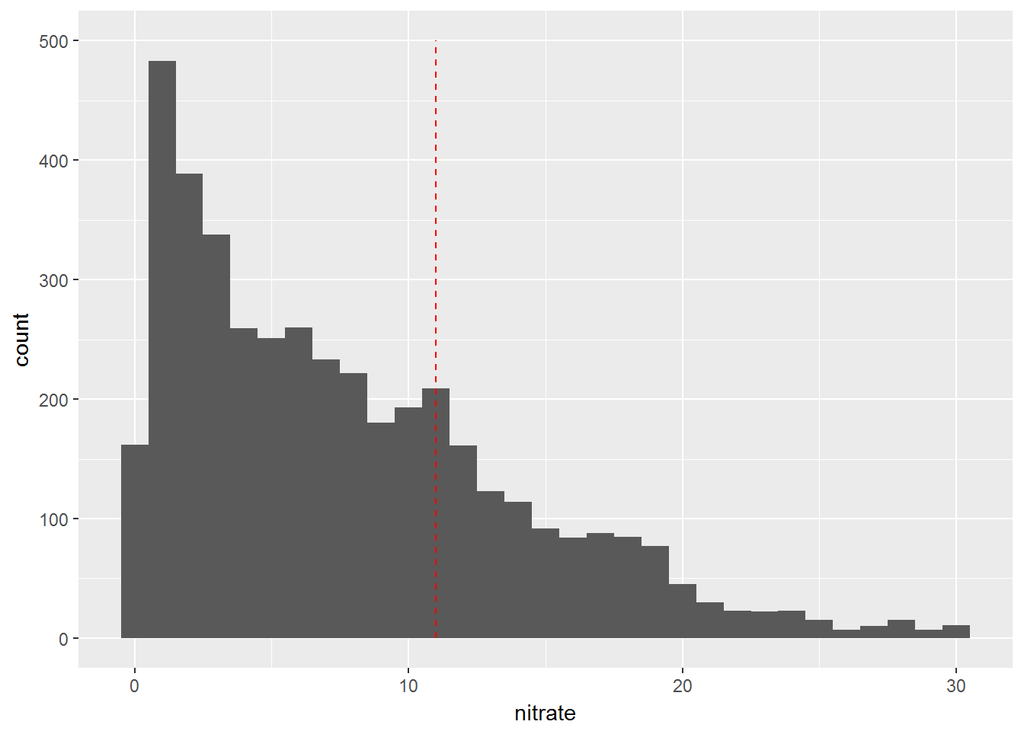

```
## [1] 0.2524341
```

As we can see there is a significant number of measurements (25%) which exeed the given threshold which is depicted by the dashed red line.

We also want to take a look at the other variables.

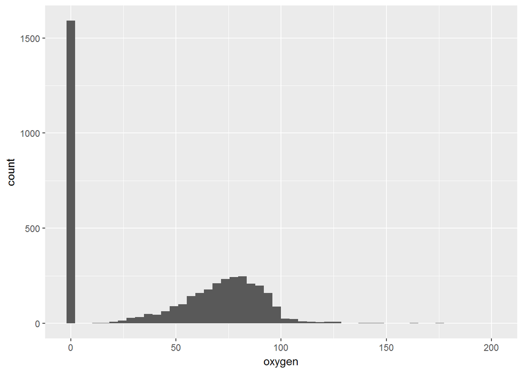

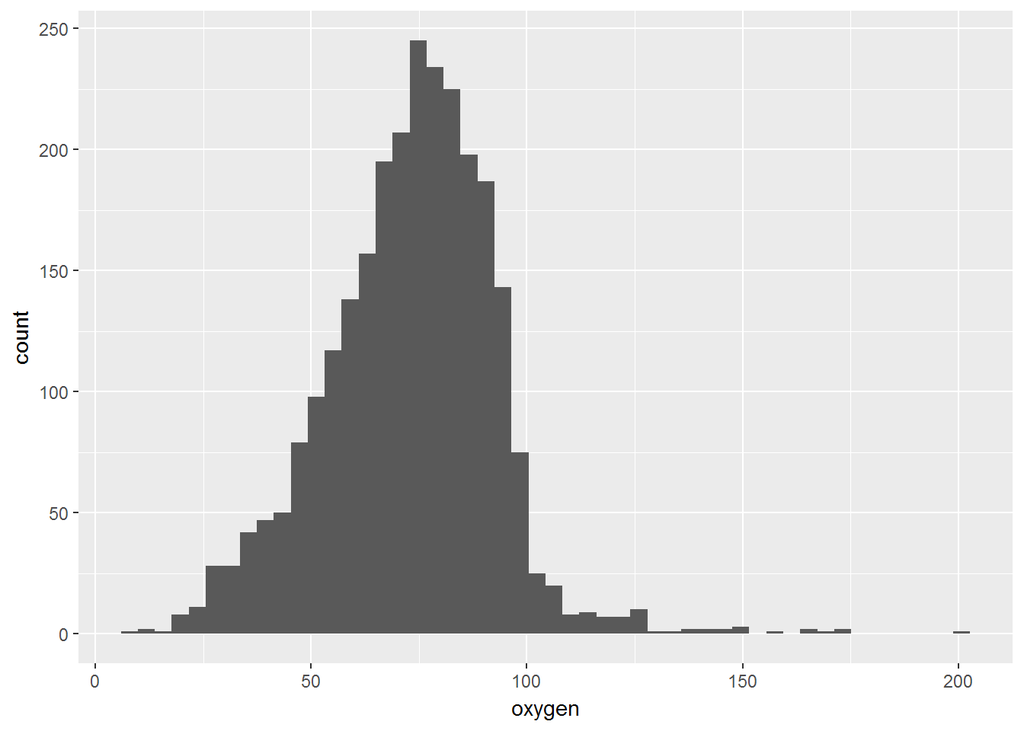

```
## [1] 2620
```

```
## [1] 0.62218
```

Oxygen has a lot of 0 measurements. The plots above show the histogram with and without the 0 measurements. These are measurements that are below the detection limit. This is important to remember once we start building our model.

We still have 2620 measuremnts or about 62% of the total if we would eliminate those with 0 measurements.

The histograms of the other univariate quantitative variables are given below.

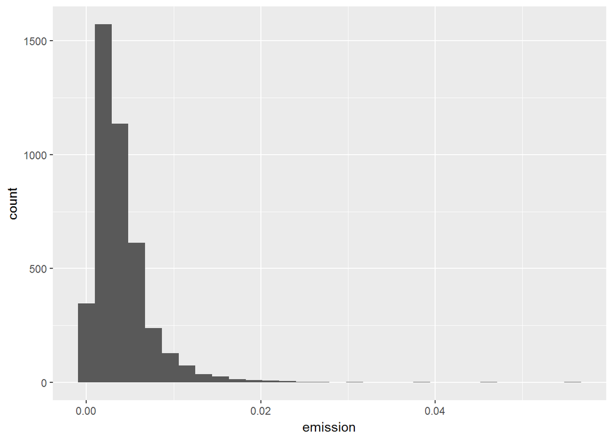

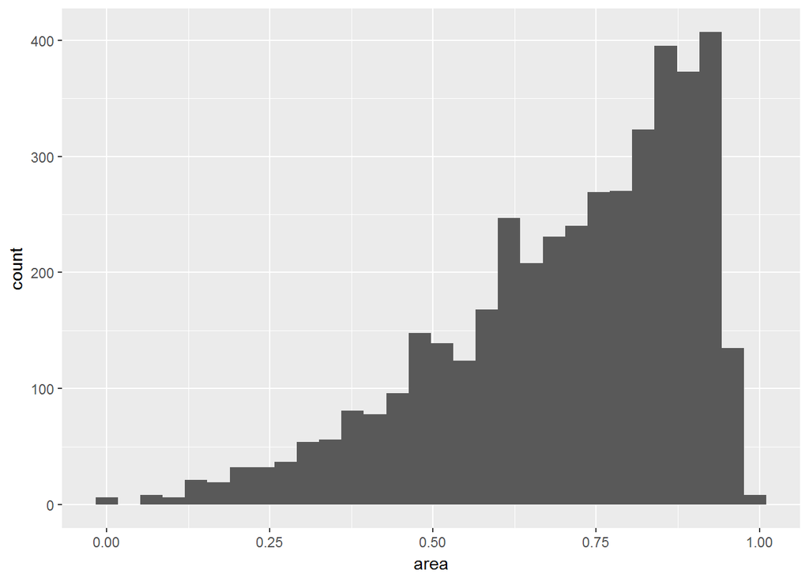

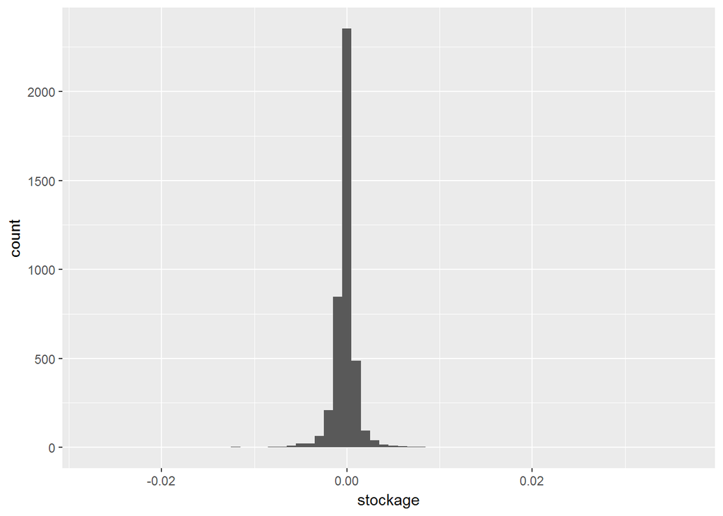

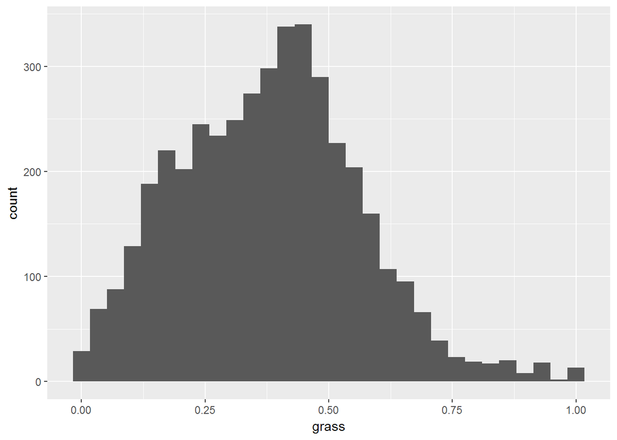

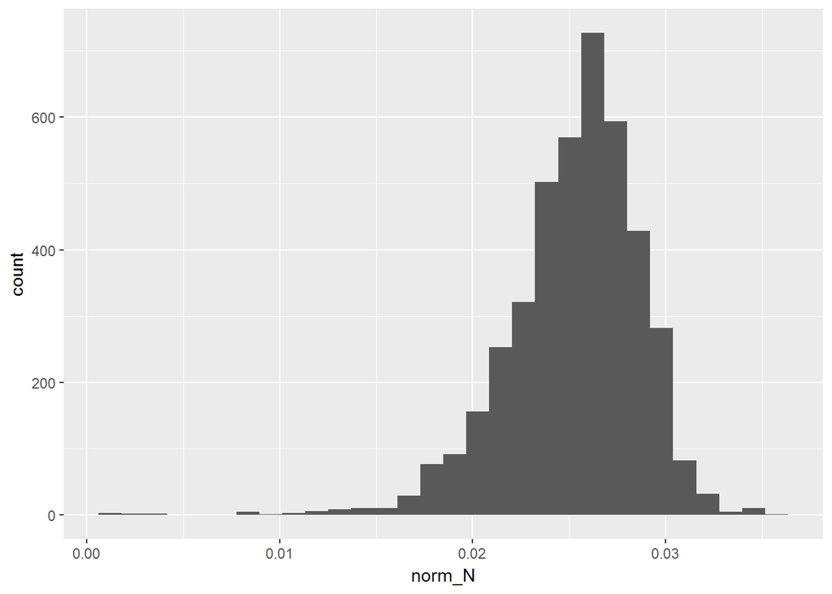

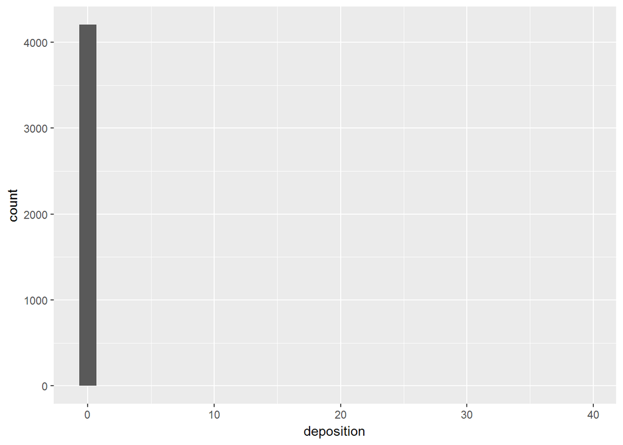

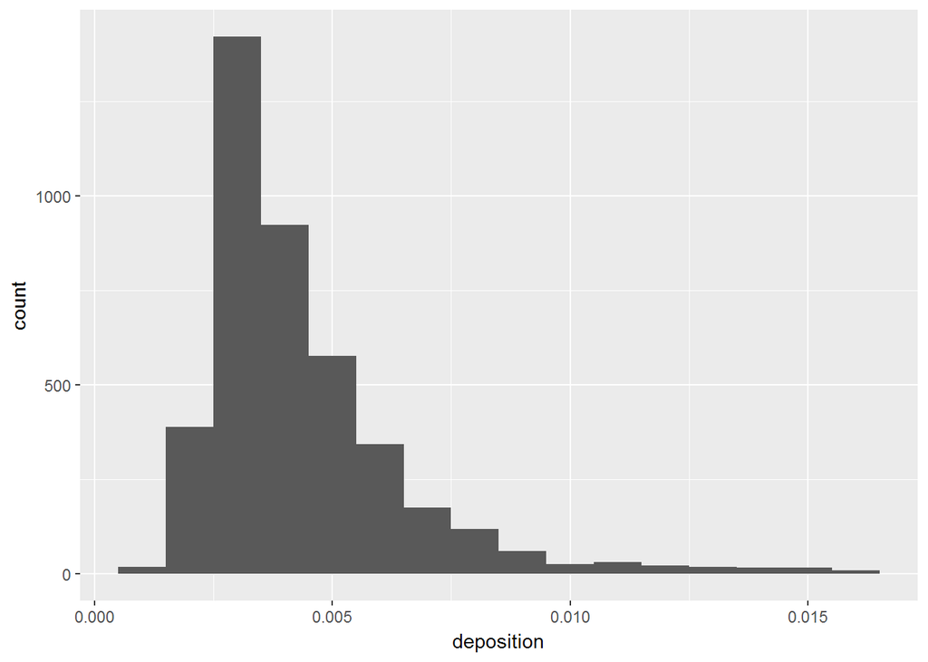

Based on these histograms we see that depostition contains a couple of outliers. These are removed from the dataset for further analysis. Apart from this, the histograms do not indicate clear outliers. It is also clear that not all data is normally distributed.

Vegetables are divided in 3 different groups containing different types of vegetables. For this exercise we lump them together in 1 group of vegetables. First we check the percentage of data for each group and the total group. That implies that the value is higher than 0.

```
## [1] 0.1799424
```

```
## [1] 0.2965451
```

```
## [1] 0.2068138
```

```
## [1] 0.3738004
```

Finally, let’s take a look at the resulting histogram, both with and without the 0 values.

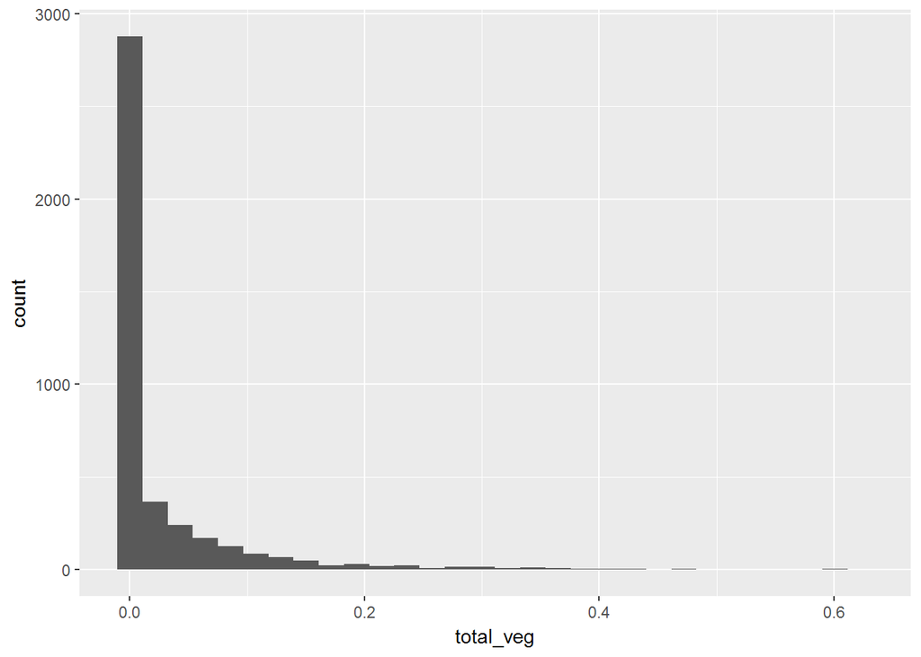

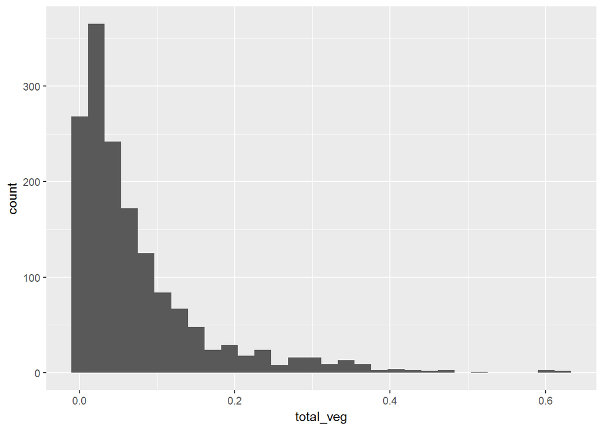

# Univariate Analysis

### What is the structure of your dataset?

The initial dataset consists of 4211 rows and 15 variabales. Each row consists of a nitrate measurement at a certain location along with some other variables linked to it.

### What is/are the main feature(s) of interest in your dataset?

The main variable of interest is the nitrate concentrations in the surface water. This concentration is still too high (related to the allowed threshold) in a number of locations despite lot of efforts.

### What other features in the dataset do you think will help support your investigation into your feature(s) of interest?

The bivariate analysis might reveal some variables that correlate to the overall measured nitrate concentrations. However, since a lot of processes determine the final concentrations we don’t expect very strong relations.

### Did you create any new variables from existing variables in the dataset?

I created the total_Veg variable which is the sum of the different groups of vegetables in the original dataset.

### Of the features you investigated, were there any unusual distributions? Did you perform any operations on the data to tidy, adjust, or change the form of the data? If so, why did you do this?

I removed some outliers in the depostion variable. Apart from that we need to note that there are a lot of 0 measurements in the oxygen variable that might influence further analysis.

# Bivariate Plots Section

First we want to investigate the trend in nitrate conccentrations in time. We plot different figures which all show similar information.

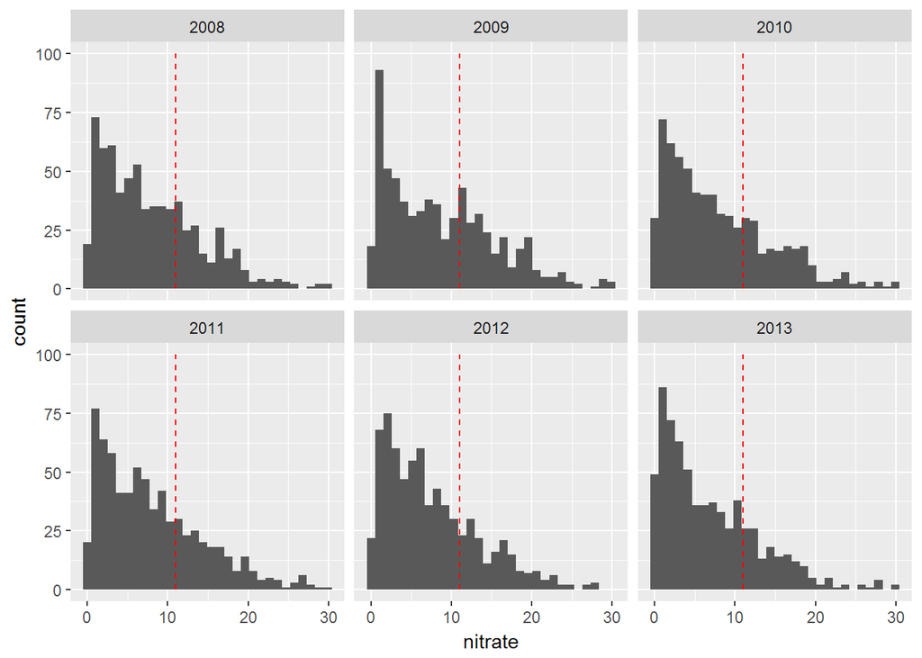

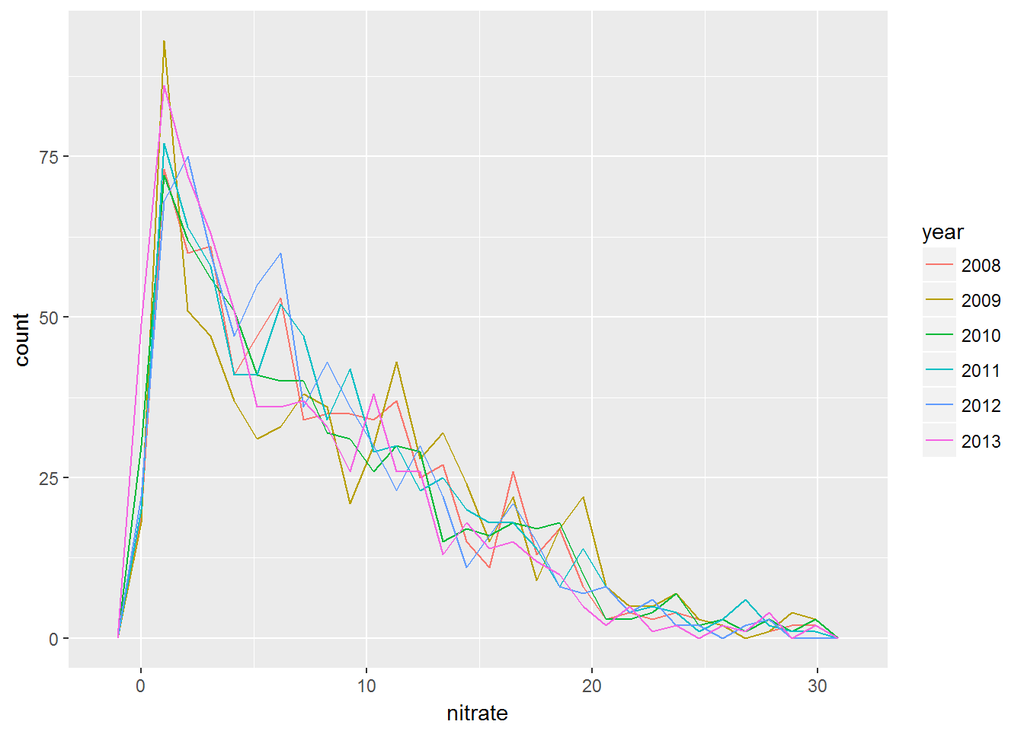

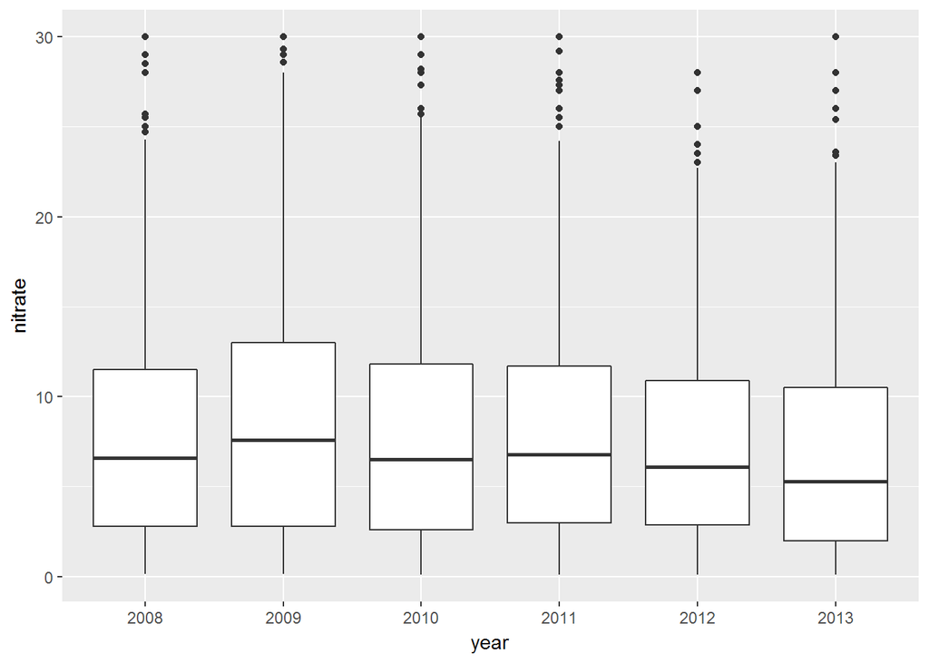

```
##    year   median_nitrate    low_quant        high_quant      nr_of_exc
##  2008:1   Min.   :5.300   Min.   :0.4420   Min.   :17.92   Min.   :144.0
##  2009:1   1st Qu.:6.200   1st Qu.:0.5865   1st Qu.:18.88   1st Qu.:169.0
##  2010:1   Median :6.550   Median :0.6575   Median :19.40   Median :176.0
##  2011:1   Mean   :6.483   Mean   :0.6412   Mean   :19.38   Mean   :177.2
##  2012:1   3rd Qu.:6.750   3rd Qu.:0.7322   3rd Qu.:19.99   3rd Qu.:181.5
##  2013:1   Max.   :7.600   Max.   :0.7700   Max.   :20.68   Max.   :217.0
```

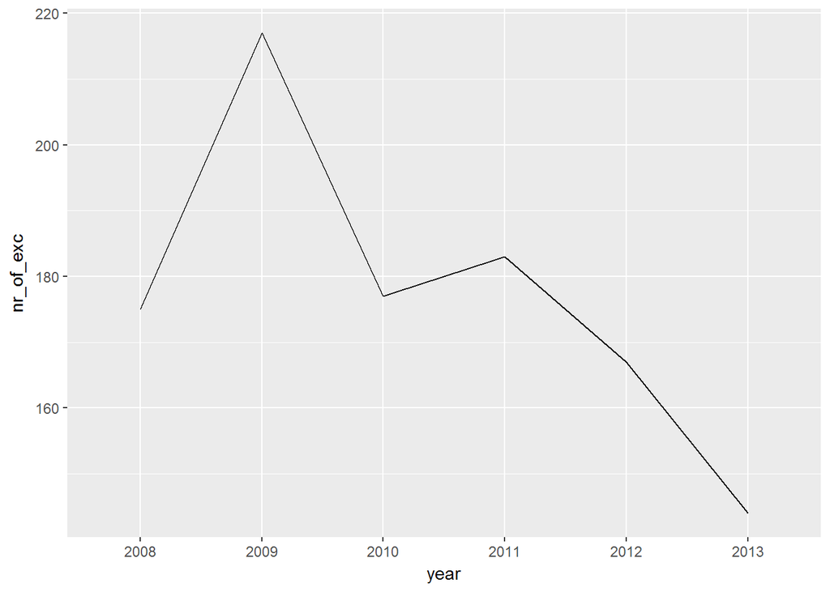

In order to get a better view on the trend in time we create a summary plot.

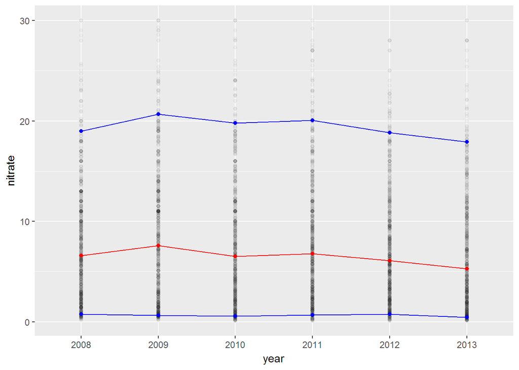

The red line in this plot shows the median concentration for each year. The blue lines show the 0.05 & 0.95 quantiles. Although this plot shows similar information as the box plot, the decreasing trend is better visualised.

Second question we have is whether or not the use of a catch crop decreases the observed concentrations in the river

```
## # A tibble: 2 x 4
##   catchcrop median_nitrate low_quant high_quant
##      <fctr>          <dbl>     <dbl>      <dbl>
## 1        no            7.4    0.7955     19.500
## 2       yes            5.7    0.5200     19.525
```

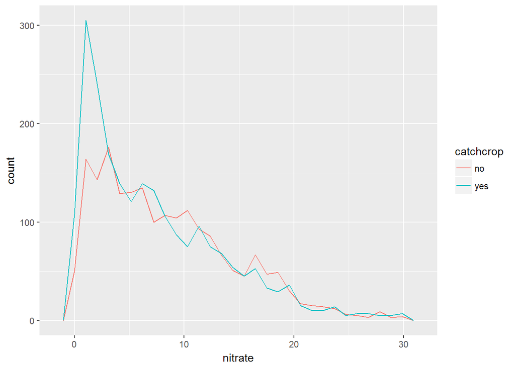

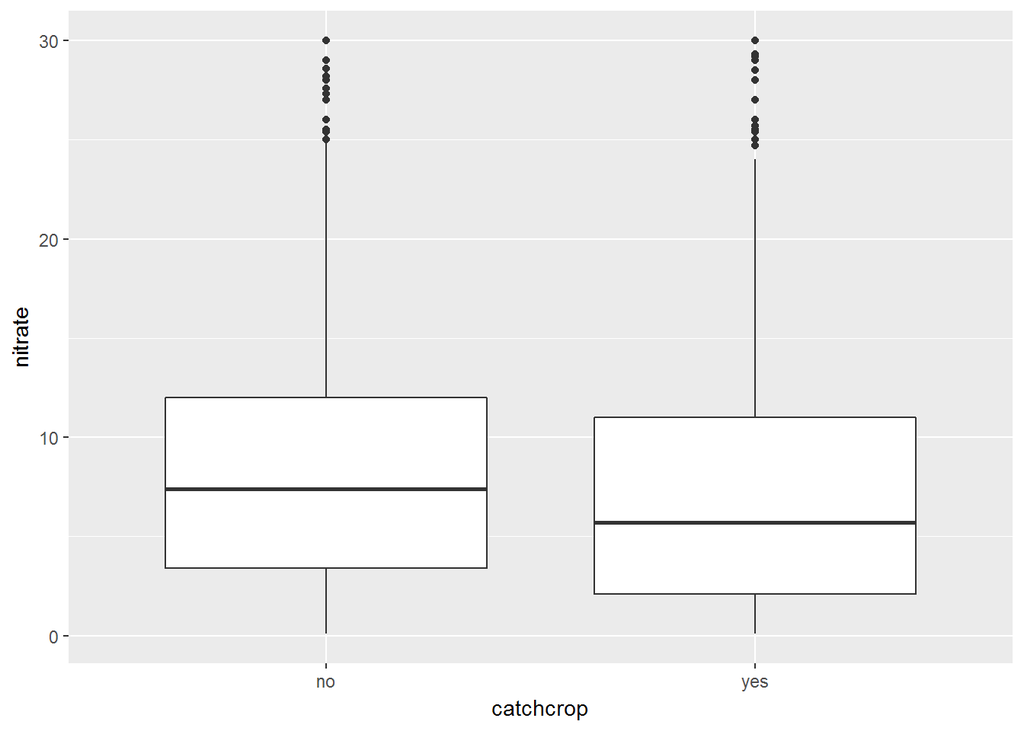

Both resulting plots and the table do show an effect of the catch crop. Median nitrate concentrations are lower if a catch crop is used.

Let’s investigate the correlations between some other quantitative variables. First we draw a scatter matrix to give a first idea of which variables are worth investigating further.

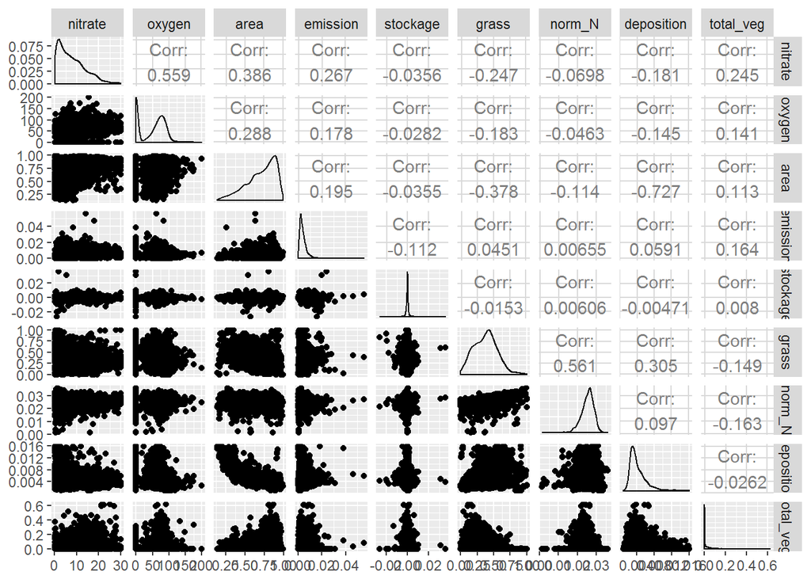

Based on this information, let’s take a closer look at some of the correlations.

Oxygen seems to have a rather high correlation coefficient.

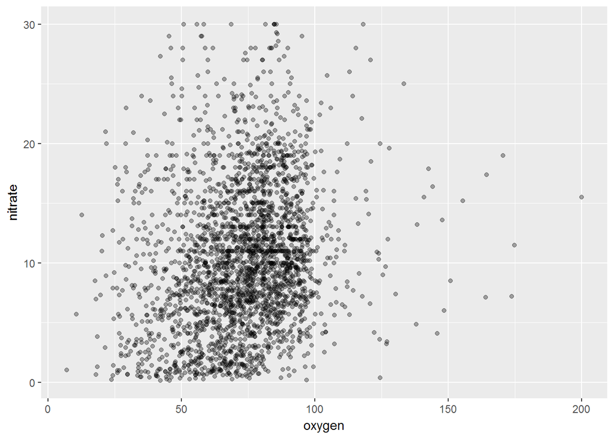

The plot does show some correlation although it is not very clear.

As well as area.

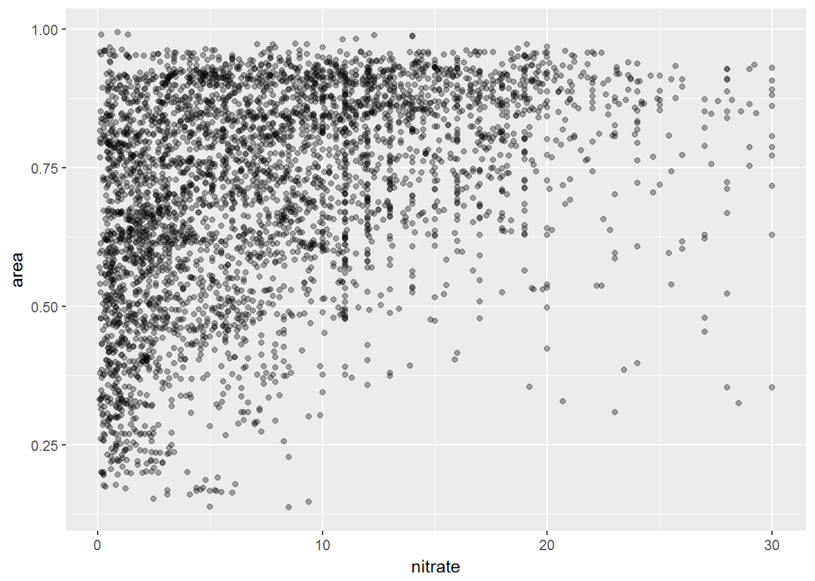

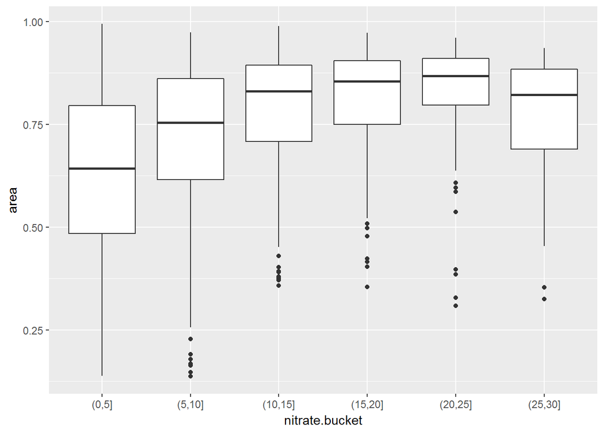

From these plots it is clear that there is a correlation between both. As the first plot was still prone to overplotting I subdived the nitrate in different buckets and plotted boxplots for each of them. This gives a clearer image of the situation. Higher nitrate concentrations have in general higher areas. As a reminder, area indicates the proporation of farmland in the upstream area.

Yet it is also clear that a lot of other factors are influencing the concentrations.

Area is also strongly linked to deposition which in itself has an inverse relation to nitrate concentrations. This is rather unexpected as we would expect that farm activities have an influence on the depostion.

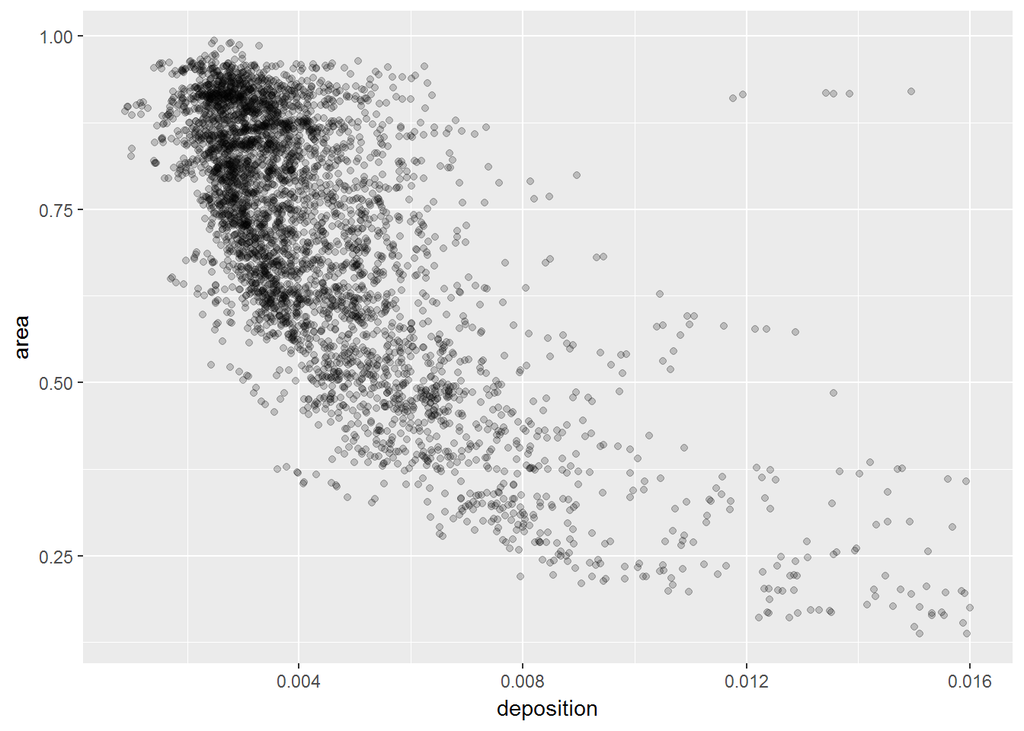

Also the variables emission, grass & total_veg have a small but existing correlation.

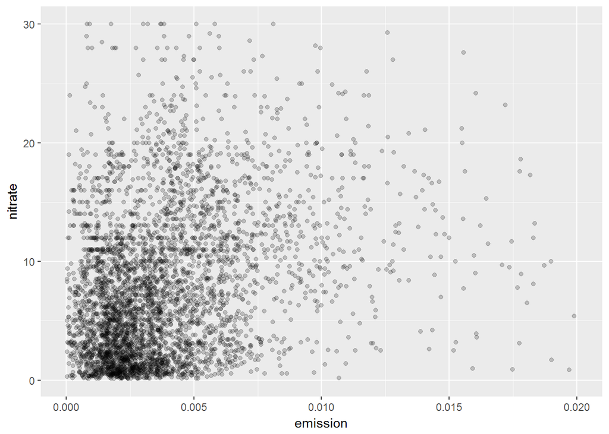

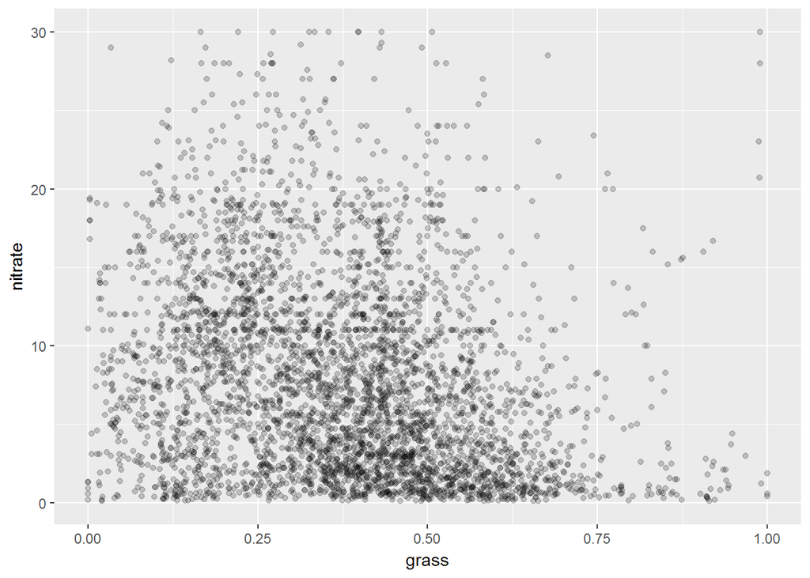

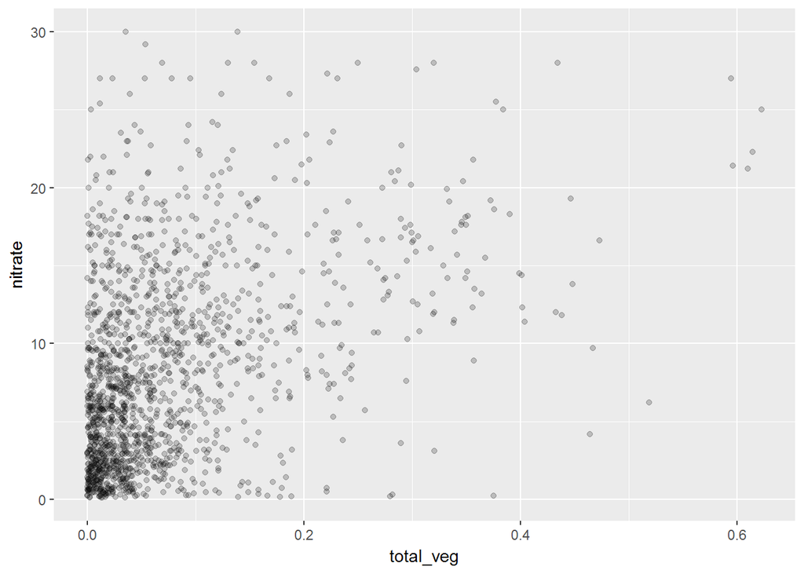

Based on the plot we would assume that the correlation between total_veg & nitrate is higher that what we observed in the correlation scatter plot. This is due to the 0 values in the total_veg variable as can be seen by comparing the correlation coefficient in both.

```
##
##  Pearson's product-moment correlation
##
## data:  nitrate and total_veg
## t = 16.312, df = 4166, p-value < 2.2e-16
## alternative hypothesis: true correlation is not equal to 0
## 95 percent confidence interval:
##  0.2162643 0.2733430
## sample estimates:
##       cor
## 0.2450159
```

```
##
##  Pearson's product-moment correlation
##
## data:  nitrate and total_veg
## t = 18.232, df = 1556, p-value < 2.2e-16
## alternative hypothesis: true correlation is not equal to 0
## 95 percent confidence interval:
##  0.3777673 0.4596432
## sample estimates:
##       cor
## 0.4195582
```

This analysis indicates that it is important to take note of the 0 values in the subsequent analysis.

# Bivariate Analysis

### Talk about some of the relationships you observed in this part of the investigation. How did the feature(s) of interest vary with other features in the dataset?

Nitrate correlates with quite some of the observed variables. yet none of the correlations is particularly strong.

### Did you observe any interesting relationships between the other features (not the main feature(s) of interest)?

Yes. There was a high correlation between depostion and area which was rather unexpected.

### What was the strongest relationship you found?

The strongest relation could be obsvered between nitrate and oxygen. This is a logical conclusions since oxygen levels will be influence by nitrate concentrations.

# Multivariate Plots Section

Before going to our main variable (nitrate) I just want to highlight that area is also strongly linked to deposition which in itself has an inverse relation to nitrate concentrations. All of this can be seen in the following plot.

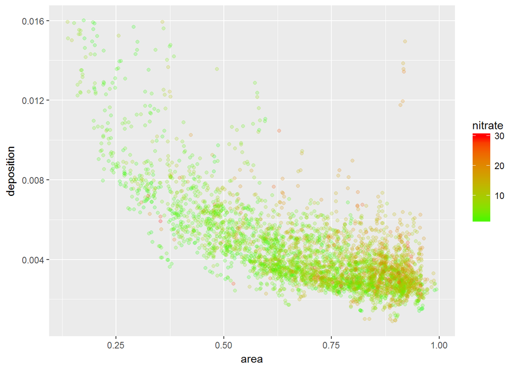

The correlations between nitrate and other variables are rather week and plots similar to the above do not really bring much new insights.

Therefore we will try to develop a linear model in this section to predict nitrate concentrations in the river

```
##
## Calls:
## fit1: lm(formula = nitrate ~ oxygen, data = nc)
## fit2: lm(formula = nitrate ~ oxygen + area, data = nc)
## fit3: lm(formula = nitrate ~ oxygen + area + emission, data = nc)
## fit4: lm(formula = nitrate ~ oxygen + area + emission + grass, data = nc)
## fit5: lm(formula = nitrate ~ oxygen + area + emission + grass + total_veg,
##     data = nc)
## fit6: lm(formula = nitrate ~ oxygen + area + emission + grass + total_veg +
##     catchcrop, data = nc)
##
## ===============================================================================================================
##                          fit1           fit2           fit3           fit4           fit5           fit6
## ---------------------------------------------------------------------------------------------------------------
##   (Intercept)             3.714***      -1.612***      -1.980***       0.196         -0.127         -0.136
##                          (0.124)        (0.304)        (0.301)        (0.415)        (0.411)        (0.414)
##   oxygen                  0.090***       0.079***       0.076***       0.074***       0.072***       0.072***
##                          (0.002)        (0.002)        (0.002)        (0.002)        (0.002)        (0.002)
##   area                                   8.237***       7.499***       6.238***       6.212***       6.223***
##                                         (0.432)        (0.431)        (0.459)        (0.454)        (0.458)
##   emission                                            258.063***     283.053***     247.328***     246.867***
##                                                       (22.988)       (23.073)       (23.048)       (23.176)
##   grass                                                               -3.471***      -2.863***      -2.899***
##                                                                       (0.460)        (0.458)        (0.494)
##   total_veg                                                                          12.041***      12.035***
##                                                                                      (1.167)        (1.168)
##   catchcrop: yes/no                                                                                  0.032
##                                                                                                     (0.167)
## ---------------------------------------------------------------------------------------------------------------
##   R-squared               0.312          0.367          0.386          0.394          0.409          0.409
##   adj. R-squared          0.312          0.367          0.385          0.394          0.409          0.408
##   sigma                   5.157          4.946          4.874          4.841          4.781          4.782
##   F                    1889.542       1208.613        871.938        677.009        576.597        480.393
##   p                       0.000          0.000          0.000          0.000          0.000          0.000
##   Log-likelihood     -12750.141     -12575.837     -12513.698     -12485.345     -12432.742     -12432.723
##   Deviance           110793.609     101903.886      98910.262      97573.671      95141.581      95140.743
##   AIC                 25506.282      25159.674      25037.397      24982.690      24879.483      24881.446
##   BIC                 25525.287      25185.015      25069.073      25020.701      24923.829      24932.128
##   N                    4168           4168           4168           4168           4168           4168
## ===============================================================================================================
```

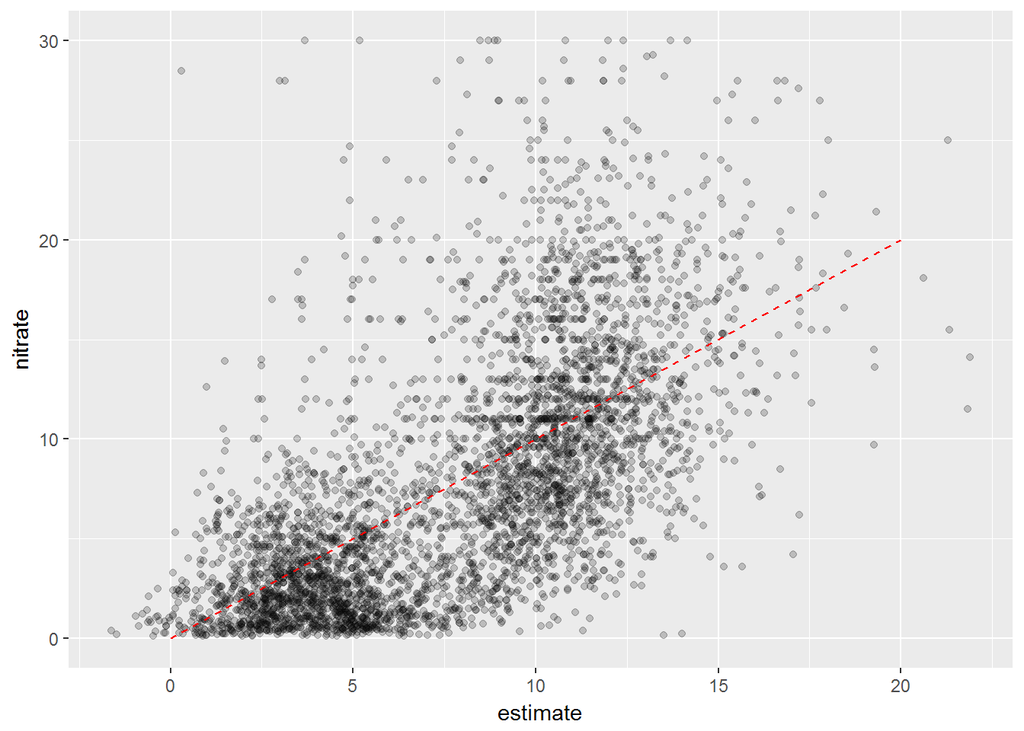

The last plot shows the measured values against the predicted values based on the lineair regression model (fit5). We did not include the last variable (catchcrop) in the equations since it did not result in further improvement of the model. This plot indicates that the model is capable of capturing some of the observed variance but that it is far from perfect.

# Multivariate Analysis

### Talk about some of the relationships you observed in this part of the investigation. Were there features that strengthened each other in terms of looking at your feature(s) of interest?

We could not find clear variables that strengthened each other based on the plots.

### Did you create any models with your dataset? Discuss the strengths and limitations of your model.

The R-square of the model is 0.409 which is not great. The plot with the comparison between measured and predcited concentrations also indicates that is capable of capturing some of the observed variance but that it is far from perfect.

# Final Plots and Summary

### Plot One

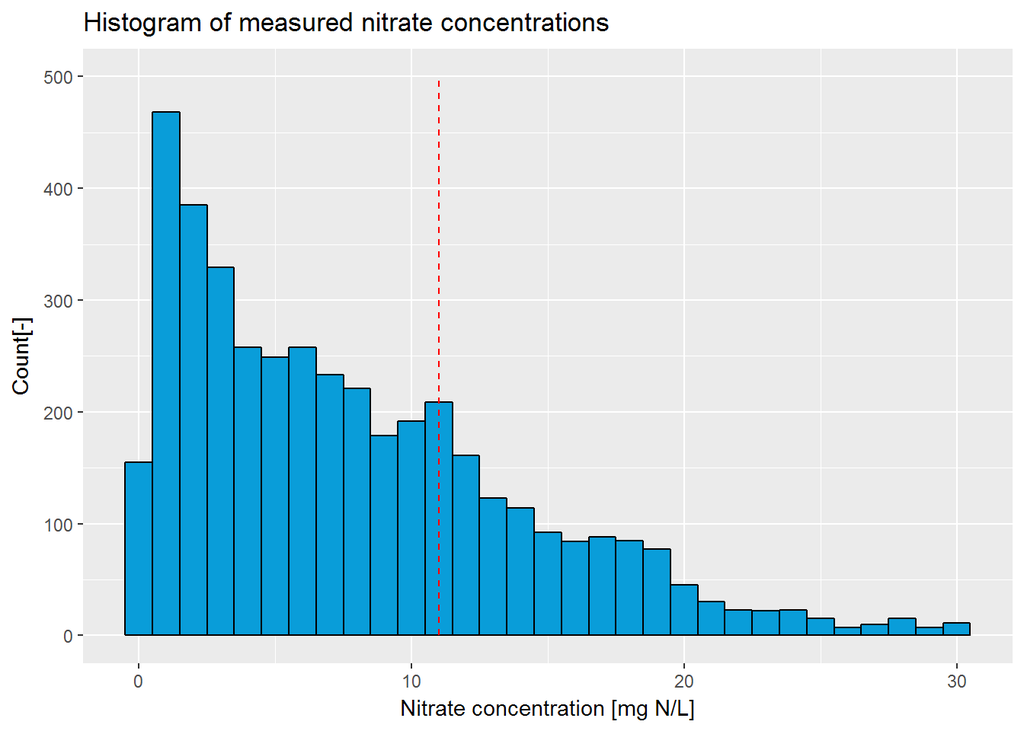

### Description One

This plot forms the basis for this exploration. It shows a histogram of nitrate concentrations in Flemish rivers, indicating the allowed threshold of 11.3 mg N/L. This plot clearly shows that there is a significant number of measurement locations that exceed this threshold.

### Plot Two

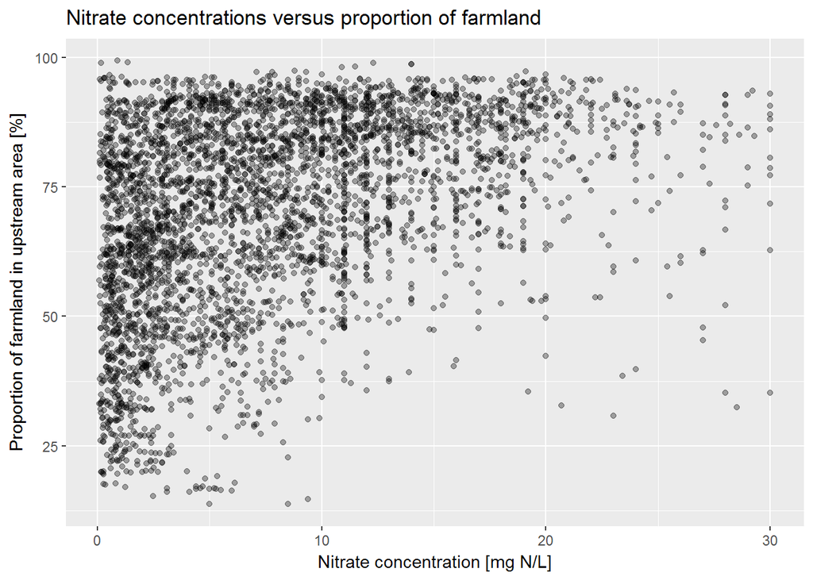

### Description Two

This plot indicates that there is a relation between the proportion of farmland in the upstream area and the nitrate concentrations measured in the river. This is an important conclusion as it indicates that human behaviour is (partly) responsible for the measured concentrations. Yet it also becomes clear from this plot that there are still other influencing factors.

### Plot Three

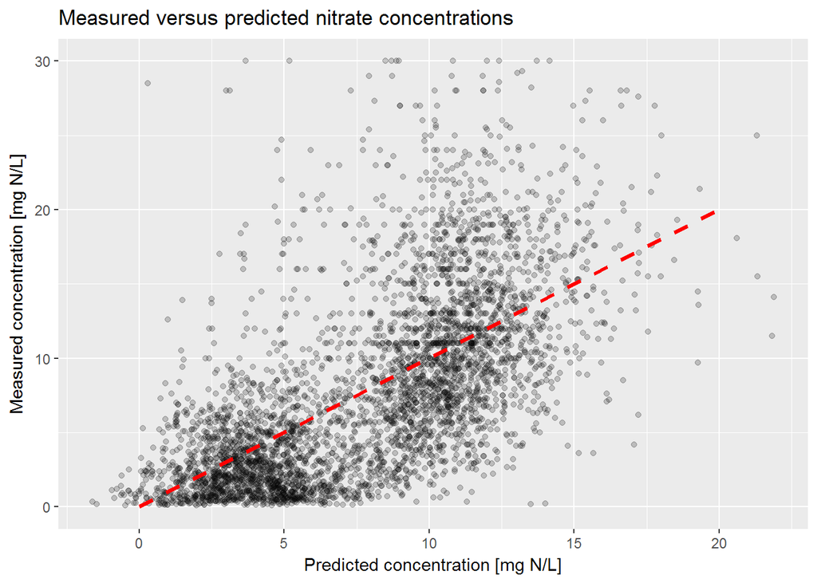

### Description Three

This plot shows the comparison between measured and predicted nitrate concentrations. The predicted concentrations are based upon a linear model that includes the variables:

- oxygen
- area
- emission
- grass
- total vegetables

This plot shows that we can explain some of the observed variance based on these variables but definetly not all.

# Reflection

This dataset contains 4211 measurments of nitrate and related variables in rivers in Flanders. About 25% of the measurement locations exceeds the prescribed threshold of 11.3 mg N/L. Based on a (rudimentary) trend analysis we can conclude that this number is decreasing over the past years.

We can conclude from the bivariate analysis that nitrate concentrations correlate well with oxygen in the water and the proportion of farmland in the upstream are. Also other variables such as the area of grassland, vegetable and emmission of N by animals is correlated with nitrate concentrations.

Furthermore we found that a large proportion of the data contains a high number of 0 values in the dataset. This is important to take into account in further investigations.

The linear model we set up indicated that we can explain some of the observed variance based on the variables in our dataset but definetly not all, which could be further investigated in future work.

The dataset we used still contains a limited number of variables and does e.g. not contain any information related to physical or chemical properties of the soil such as e.g. soil texture which might influence nitrate concentrations as well. For future work it might be worth including such variables in the analysis.